# ANCOVA in Vocabulario Ensinado (Vocabulario Ensinado)

Geiser C. Challco geiser@alumni.usp.br

- Descriptive Statistics of Initial Data
- ANCOVA and Pairwise for one factor: **grupo**
  - Without remove non-normal data
  - Computing ANCOVA and PairWise After removing non-normal data (OK)
    - Plots for ancova
    - Checking linearity assumption
    - Checking normality and homogeneity
- ANCOVA and Pairwise for two factors **grupo:Sexo**
  - Without remove non-normal data
  - Computing ANCOVA and PairWise After removing non-normal data (OK)
    - Plots for ancova
    - Checking linearity assumption
    - Checking normality and homogeneity
- ANCOVA and Pairwise for two factors **grupo:Zona**
  - Without remove non-normal data
  - Computing ANCOVA and PairWise After removing non-normal data (OK)
    - Plots for ancova
    - Checking linearity assumption
    - Checking normality and homogeneity
- ANCOVA and Pairwise for two factors **grupo:Cor.Raca**
  - Without remove non-normal data
  - Computing ANCOVA and PairWise After removing non-normal data (OK)
    - Plots for ancova
    - Checking linearity assumption
    - Checking normality and homogeneity
- ANCOVA and Pairwise for two factors **grupo:vocab.teach.quintile**
  - Without remove non-normal data
  - Computing ANCOVA and PairWise After removing non-normal data (OK)
    - Plots for ancova
    - Checking linearity assumption
    - Checking normality and homogeneity
- Summary of Results
  - Descriptive Statistics
  - ANCOVA Table Comparison
  - PairWise Table Comparison
  - EMMS Table Comparison

**NOTE**:

- Teste ANCOVA para determinar se houve diferenças significativas no Vocabulario Ensinado (medido usando pre- e pos-testes).
- ANCOVA test to determine whether there were significant differences in Vocabulario Ensinado (measured using pre- and post-tests).

# Descriptive Statistics of Initial Data

```r
df <- get.descriptives(dat, c(dv.pre, dv.pos), c("grupo"),
                       include.global = T, symmetry.test = T, normality.test = F)
df <- plyr::rbind.fill(
  df, do.call(plyr::rbind.fill, lapply(lfatores2, FUN = function(f) {
    if (nrow(dat) > 0 && sum(!is.na(unique(dat[[f]]))) > 1)
      get.descriptives(dat, c(dv.pre,dv.pos), c("grupo", f),
                       symmetry.test = T, normality.test = F)
    }))
)
(df <- df[,c(fatores1[fatores1 %in% colnames(df)],"variable",
             colnames(df)[!colnames(df) %in% c(fatores1,"variable")])])
```

```
##           grupo Sexo   Zona Cor.Raca vocab.teach.quintile        variable   n  mean median min max    sd    se
## 1      Controle <NA>   <NA>     <NA>                 <NA> vocab.teach.pre 152 4.013    4.0   1  11 1.919 0.156
## 2  Experimental <NA>   <NA>     <NA>                 <NA> vocab.teach.pre 196 4.745    5.0   1  13 2.157 0.154
## 3          <NA> <NA>   <NA>     <NA>                 <NA> vocab.teach.pre 348 4.425    4.0   1  13 2.085 0.112
## 4      Controle <NA>   <NA>     <NA>                 <NA> vocab.teach.pos 152 4.658    5.0   0  10 2.040 0.165
## 5  Experimental <NA>   <NA>     <NA>                 <NA> vocab.teach.pos 196 4.980    5.0   0  11 2.134 0.152
## 6          <NA> <NA>   <NA>     <NA>                 <NA> vocab.teach.pos 348 4.839    5.0   0  11 2.096 0.112
## 7      Controle    F   <NA>     <NA>                 <NA> vocab.teach.pre  85 4.259    4.0   1   9 1.767 0.192
## 8      Controle    M   <NA>     <NA>                 <NA> vocab.teach.pre  67 3.701    3.0   1  11 2.067 0.253
## 9  Experimental    F   <NA>     <NA>                 <NA> vocab.teach.pre  98 4.653    4.0   1  13 2.271 0.229
## 10 Experimental    M   <NA>     <NA>                 <NA> vocab.teach.pre  98 4.837    5.0   1   9 2.044 0.207
## 11     Controle    F   <NA>     <NA>                 <NA> vocab.teach.pos  85 4.800    5.0   0  10 1.969 0.214
## 12     Controle    M   <NA>     <NA>                 <NA> vocab.teach.pos  67 4.478    4.0   1  10 2.127 0.260
## 13 Experimental    F   <NA>     <NA>                 <NA> vocab.teach.pos  98 5.010    5.0   1  11 2.137 0.216
## 14 Experimental    M   <NA>     <NA>                 <NA> vocab.teach.pos  98 4.949    5.0   0  11 2.141 0.216
```

[output cut: 98 more lines]

| grupo | Sexo | Zona | Cor.Raca | vocab.teach.quintile | variable | n | mean | median | min | max | sd | se | ci | iqr | symmetry | skewness | kurtosis |
| --- | --- | --- | --- | --- | --- | --- | --- | --- | --- | --- | --- | --- | --- | --- | --- | --- | --- |
| Controle |  |  |  |  | vocab.teach.pre | 152 | 4.013 | 4.0 | 1 | 11 | 1.919 | 0.156 | 0.308 | 2.00 | NO | 0.685 | 0.547 |
| Experimental |  |  |  |  | vocab.teach.pre | 196 | 4.745 | 5.0 | 1 | 13 | 2.157 | 0.154 | 0.304 | 3.00 | NO | 0.549 | 0.323 |
|  |  |  |  |  | vocab.teach.pre | 348 | 4.425 | 4.0 | 1 | 13 | 2.085 | 0.112 | 0.220 | 3.00 | NO | 0.632 | 0.449 |
| Controle |  |  |  |  | vocab.teach.pos | 152 | 4.658 | 5.0 | 0 | 10 | 2.040 | 0.165 | 0.327 | 3.00 | YES | 0.287 | -0.267 |
| Experimental |  |  |  |  | vocab.teach.pos | 196 | 4.980 | 5.0 | 0 | 11 | 2.134 | 0.152 | 0.301 | 3.00 | YES | 0.405 | -0.068 |
|  |  |  |  |  | vocab.teach.pos | 348 | 4.839 | 5.0 | 0 | 11 | 2.096 | 0.112 | 0.221 | 3.00 | YES | 0.366 | -0.099 |
| Controle | F |  |  |  | vocab.teach.pre | 85 | 4.259 | 4.0 | 1 | 9 | 1.767 | 0.192 | 0.381 | 2.00 | YES | 0.428 | -0.333 |
| Controle | M |  |  |  | vocab.teach.pre | 67 | 3.701 | 3.0 | 1 | 11 | 2.067 | 0.253 | 0.504 | 3.00 | NO | 1.025 | 1.411 |
| Experimental | F |  |  |  | vocab.teach.pre | 98 | 4.653 | 4.0 | 1 | 13 | 2.271 | 0.229 | 0.455 | 3.00 | NO | 0.898 | 1.069 |
| Experimental | M |  |  |  | vocab.teach.pre | 98 | 4.837 | 5.0 | 1 | 9 | 2.044 | 0.207 | 0.410 | 3.75 | YES | 0.090 | -0.780 |
| Controle | F |  |  |  | vocab.teach.pos | 85 | 4.800 | 5.0 | 0 | 10 | 1.969 | 0.214 | 0.425 | 3.00 | YES | 0.054 | -0.320 |
| Controle | M |  |  |  | vocab.teach.pos | 67 | 4.478 | 4.0 | 1 | 10 | 2.127 | 0.260 | 0.519 | 3.00 | NO | 0.556 | -0.152 |
| Experimental | F |  |  |  | vocab.teach.pos | 98 | 5.010 | 5.0 | 1 | 11 | 2.137 | 0.216 | 0.428 | 2.00 | YES | 0.489 | -0.033 |
| Experimental | M |  |  |  | vocab.teach.pos | 98 | 4.949 | 5.0 | 0 | 11 | 2.141 | 0.216 | 0.429 | 3.00 | YES | 0.315 | -0.171 |
| Controle |  | Rural |  |  | vocab.teach.pre | 77 | 4.117 | 4.0 | 1 | 11 | 1.967 | 0.224 | 0.446 | 2.00 | NO | 1.017 | 1.108 |
| Controle |  | Urbana |  |  | vocab.teach.pre | 50 | 4.140 | 4.0 | 1 | 8 | 1.629 | 0.230 | 0.463 | 2.00 | YES | 0.168 | -0.479 |
| Controle |  |  |  |  | vocab.teach.pre | 25 | 3.440 | 3.0 | 1 | 9 | 2.256 | 0.451 | 0.931 | 4.00 | NO | 0.619 | -0.598 |
| Experimental |  | Rural |  |  | vocab.teach.pre | 92 | 4.707 | 4.0 | 1 | 11 | 2.105 | 0.219 | 0.436 | 3.00 | YES | 0.427 | -0.310 |
| Experimental |  | Urbana |  |  | vocab.teach.pre | 75 | 4.760 | 5.0 | 1 | 13 | 2.324 | 0.268 | 0.535 | 3.00 | NO | 0.715 | 0.823 |
| Experimental |  |  |  |  | vocab.teach.pre | 29 | 4.828 | 4.0 | 1 | 9 | 1.929 | 0.358 | 0.734 | 3.00 | YES | 0.207 | -0.826 |
| Controle |  | Rural |  |  | vocab.teach.pos | 77 | 5.013 | 5.0 | 1 | 10 | 2.074 | 0.236 | 0.471 | 3.00 | YES | 0.280 | -0.589 |
| Controle |  | Urbana |  |  | vocab.teach.pos | 50 | 4.480 | 4.0 | 0 | 9 | 1.876 | 0.265 | 0.533 | 2.75 | YES | -0.169 | -0.188 |
| Controle |  |  |  |  | vocab.teach.pos | 25 | 3.920 | 4.0 | 1 | 10 | 2.080 | 0.416 | 0.859 | 3.00 | NO | 0.955 | 0.643 |
| Experimental |  | Rural |  |  | vocab.teach.pos | 92 | 5.065 | 5.0 | 0 | 11 | 2.267 | 0.236 | 0.469 | 3.25 | YES | 0.402 | -0.161 |
| Experimental |  | Urbana |  |  | vocab.teach.pos | 75 | 5.093 | 5.0 | 1 | 11 | 2.170 | 0.251 | 0.499 | 4.00 | YES | 0.234 | -0.394 |
| Experimental |  |  |  |  | vocab.teach.pos | 29 | 4.414 | 4.0 | 2 | 8 | 1.476 | 0.274 | 0.562 | 1.00 | YES | 0.323 | -0.384 |
| Controle |  |  | Branca |  | vocab.teach.pre | 22 | 4.000 | 4.0 | 1 | 11 | 2.289 | 0.488 | 1.015 | 2.50 | NO | 1.206 | 1.655 |
| Controle |  |  | Indígena |  | vocab.teach.pre | 8 | 3.875 | 4.0 | 1 | 6 | 1.458 | 0.515 | 1.219 | 0.50 | NO | -0.541 | -0.484 |
| Controle |  |  | Parda |  | vocab.teach.pre | 44 | 3.727 | 3.0 | 1 | 8 | 1.835 | 0.277 | 0.558 | 2.00 | NO | 0.704 | -0.248 |
| Controle |  |  |  |  | vocab.teach.pre | 78 | 4.192 | 4.0 | 1 | 9 | 1.907 | 0.216 | 0.430 | 2.00 | YES | 0.415 | -0.117 |
| Experimental |  |  | Branca |  | vocab.teach.pre | 12 | 4.500 | 4.0 | 2 | 7 | 1.567 | 0.452 | 0.995 | 1.50 | YES | 0.260 | -1.164 |
| Experimental |  |  | Indígena |  | vocab.teach.pre | 2 | 4.000 | 4.0 | 1 | 7 | 4.243 | 3.000 | 38.119 | 3.00 | few data | 0.000 | 0.000 |
| Experimental |  |  | Parda |  | vocab.teach.pre | 52 | 4.365 | 4.0 | 1 | 10 | 2.077 | 0.288 | 0.578 | 3.00 | NO | 0.702 | -0.046 |
| Experimental |  |  |  |  | vocab.teach.pre | 130 | 4.931 | 5.0 | 1 | 13 | 2.207 | 0.194 | 0.383 | 3.00 | NO | 0.503 | 0.416 |
| Controle |  |  | Branca |  | vocab.teach.pos | 22 | 4.500 | 4.5 | 1 | 9 | 1.896 | 0.404 | 0.841 | 2.75 | YES | 0.300 | -0.354 |
| Controle |  |  | Indígena |  | vocab.teach.pos | 8 | 5.875 | 6.0 | 3 | 9 | 1.959 | 0.693 | 1.638 | 1.75 | YES | 0.151 | -1.329 |
| Controle |  |  | Parda |  | vocab.teach.pos | 44 | 5.000 | 5.0 | 2 | 9 | 1.988 | 0.300 | 0.605 | 3.00 | YES | 0.382 | -0.694 |
| Controle |  |  |  |  | vocab.teach.pos | 78 | 4.385 | 4.0 | 0 | 10 | 2.078 | 0.235 | 0.468 | 3.00 | YES | 0.294 | -0.149 |
| Experimental |  |  | Branca |  | vocab.teach.pos | 12 | 4.833 | 5.0 | 1 | 7 | 1.899 | 0.548 | 1.207 | 2.50 | YES | -0.439 | -1.018 |
| Experimental |  |  | Indígena |  | vocab.teach.pos | 2 | 5.500 | 5.5 | 3 | 8 | 3.536 | 2.500 | 31.766 | 2.50 | few data | 0.000 | 0.000 |
| Experimental |  |  | Parda |  | vocab.teach.pos | 52 | 4.808 | 5.0 | 1 | 10 | 1.941 | 0.269 | 0.540 | 2.00 | YES | 0.487 | 0.359 |
| Experimental |  |  |  |  | vocab.teach.pos | 130 | 5.054 | 5.0 | 0 | 11 | 2.228 | 0.195 | 0.387 | 4.00 | YES | 0.400 | -0.222 |
| Controle |  |  |  | 1st quintile | vocab.teach.pre | 33 | 1.636 | 2.0 | 1 | 2 | 0.489 | 0.085 | 0.173 | 1.00 | few data | 0.000 | 0.000 |
| Controle |  |  |  | 2nd quintile | vocab.teach.pre | 33 | 3.000 | 3.0 | 3 | 3 | 0.000 | 0.000 | 0.000 | 0.00 | few data | 0.000 | 0.000 |
| Controle |  |  |  | 3rd quintile | vocab.teach.pre | 57 | 4.456 | 4.0 | 4 | 5 | 0.503 | 0.067 | 0.133 | 1.00 | few data | 0.000 | 0.000 |
| Controle |  |  |  | 4th quintile | vocab.teach.pre | 13 | 6.000 | 6.0 | 6 | 6 | 0.000 | 0.000 | 0.000 | 0.00 | few data | 0.000 | 0.000 |
| Controle |  |  |  | 5th quintile | vocab.teach.pre | 16 | 7.812 | 7.0 | 7 | 11 | 1.167 | 0.292 | 0.622 | 1.25 | NO | 1.281 | 0.808 |
| Experimental |  |  |  | 1st quintile | vocab.teach.pre | 27 | 1.667 | 2.0 | 1 | 2 | 0.480 | 0.092 | 0.190 | 1.00 | few data | 0.000 | 0.000 |
| Experimental |  |  |  | 2nd quintile | vocab.teach.pre | 36 | 3.000 | 3.0 | 3 | 3 | 0.000 | 0.000 | 0.000 | 0.00 | few data | 0.000 | 0.000 |
| Experimental |  |  |  | 3rd quintile | vocab.teach.pre | 66 | 4.500 | 4.5 | 4 | 5 | 0.504 | 0.062 | 0.124 | 1.00 | few data | 0.000 | 0.000 |
| Experimental |  |  |  | 4th quintile | vocab.teach.pre | 26 | 6.000 | 6.0 | 6 | 6 | 0.000 | 0.000 | 0.000 | 0.00 | few data | 0.000 | 0.000 |
| Experimental |  |  |  | 5th quintile | vocab.teach.pre | 41 | 7.902 | 7.0 | 7 | 13 | 1.281 | 0.200 | 0.404 | 1.00 | NO | 1.919 | 4.350 |
| Controle |  |  |  | 1st quintile | vocab.teach.pos | 33 | 3.424 | 3.0 | 1 | 7 | 1.714 | 0.298 | 0.608 | 2.00 | YES | 0.468 | -0.736 |
| Controle |  |  |  | 2nd quintile | vocab.teach.pos | 33 | 4.424 | 4.0 | 2 | 9 | 1.562 | 0.272 | 0.554 | 1.00 | NO | 0.685 | 0.587 |
| Controle |  |  |  | 3rd quintile | vocab.teach.pos | 57 | 4.807 | 5.0 | 0 | 10 | 1.885 | 0.250 | 0.500 | 3.00 | YES | 0.164 | 0.206 |
| Controle |  |  |  | 4th quintile | vocab.teach.pos | 13 | 5.462 | 6.0 | 1 | 9 | 2.665 | 0.739 | 1.610 | 4.00 | YES | -0.314 | -1.351 |
| Controle |  |  |  | 5th quintile | vocab.teach.pos | 16 | 6.500 | 6.0 | 2 | 10 | 1.932 | 0.483 | 1.030 | 1.50 | YES | -0.208 | -0.045 |
| Experimental |  |  |  | 1st quintile | vocab.teach.pos | 27 | 3.370 | 3.0 | 1 | 7 | 1.548 | 0.298 | 0.612 | 1.50 | YES | 0.473 | -0.420 |
| Experimental |  |  |  | 2nd quintile | vocab.teach.pos | 36 | 4.250 | 4.0 | 1 | 9 | 1.746 | 0.291 | 0.591 | 2.00 | YES | 0.440 | -0.108 |
| Experimental |  |  |  | 3rd quintile | vocab.teach.pos | 66 | 4.848 | 5.0 | 0 | 9 | 1.817 | 0.224 | 0.447 | 2.00 | YES | -0.142 | -0.150 |
| Experimental |  |  |  | 4th quintile | vocab.teach.pos | 26 | 5.577 | 6.0 | 2 | 8 | 1.554 | 0.305 | 0.628 | 3.00 | YES | -0.169 | -0.812 |
| Experimental |  |  |  | 5th quintile | vocab.teach.pos | 41 | 6.512 | 6.0 | 2 | 11 | 2.491 | 0.389 | 0.786 | 3.00 | YES | 0.085 | -1.088 |

# ANCOVA and Pairwise for one factor: **grupo**

## Without remove non-normal data

```r
pdat = remove_group_data(dat[!is.na(dat[["grupo"]]),], "vocab.teach.pos", "grupo")

pdat.long <- rbind(pdat[,c("id","grupo")], pdat[,c("id","grupo")])
pdat.long[["time"]] <- c(rep("pre", nrow(pdat)), rep("pos", nrow(pdat)))
pdat.long[["time"]] <- factor(pdat.long[["time"]], c("pre","pos"))
pdat.long[["vocab.teach"]] <- c(pdat[["vocab.teach.pre"]], pdat[["vocab.teach.pos"]])

aov = anova_test(pdat, vocab.teach.pos ~ vocab.teach.pre + grupo)
laov[["grupo"]] <- get_anova_table(aov)
```

```r
pwc <- emmeans_test(pdat, vocab.teach.pos ~ grupo, covariate = vocab.teach.pre,
                    p.adjust.method = "bonferroni")
```

```r
pwc.long <- emmeans_test(dplyr::group_by_at(pdat.long, "grupo"),
                          vocab.teach ~ time,
                          p.adjust.method = "bonferroni")
lpwc[["grupo"]] <- plyr::rbind.fill(pwc, pwc.long)
```

```r
ds <- get.descriptives(pdat, "vocab.teach.pos", "grupo", covar = "vocab.teach.pre")
ds <- merge(ds[ds$variable != "vocab.teach.pre",],
            ds[ds$variable == "vocab.teach.pre", !colnames(ds) %in% c("variable")],
            by = "grupo", all.x = T, suffixes = c("", ".vocab.teach.pre"))
ds <- merge(get_emmeans(pwc), ds, by = "grupo", suffixes = c(".emms", ""))
ds <- ds[,c("grupo","n","mean.vocab.teach.pre","se.vocab.teach.pre","mean","se","emmean","se.emms")]

colnames(ds) <- c("grupo", "N", paste0(c("M","SE")," (pre)"),
                  paste0(c("M","SE"), " (unadj)"), paste0(c("M", "SE"), " (adj)"))

lemms[["grupo"]] <- ds
```

## Computing ANCOVA and PairWise After removing non-normal data (OK)

```r
wdat = pdat

res = residuals(lm(vocab.teach.pos ~ vocab.teach.pre + grupo, data = wdat))
non.normal = getNonNormal(res, wdat$id, plimit = 0.05)

wdat = wdat[!wdat$id %in% non.normal,]

wdat.long <- rbind(wdat[,c("id","grupo")], wdat[,c("id","grupo")])
wdat.long[["time"]] <- c(rep("pre", nrow(wdat)), rep("pos", nrow(wdat)))
wdat.long[["time"]] <- factor(wdat.long[["time"]], c("pre","pos"))
wdat.long[["vocab.teach"]] <- c(wdat[["vocab.teach.pre"]], wdat[["vocab.teach.pos"]])

ldat[["grupo"]] = wdat

(non.normal)
```

```r
aov = anova_test(wdat, vocab.teach.pos ~ vocab.teach.pre + grupo)
laov[["grupo"]] <- merge(get_anova_table(aov), laov[["grupo"]], by="Effect", suffixes = c("","'"))

(df = get_anova_table(aov))
```

```
## ANOVA Table (type II tests)
##
##            Effect DFn DFd       F        p p<.05      ges
## 1 vocab.teach.pre   1 345 112.935 5.23e-23     * 0.247000
## 2           grupo   1 345   0.058 8.09e-01       0.000169
```

| Effect | DFn | DFd | F | p | p<.05 | ges |
| --- | --- | --- | --- | --- | --- | --- |
| vocab.teach.pre | 1 | 345 | 112.935 | 0.000 | * | 0.247 |
| grupo | 1 | 345 | 0.058 | 0.809 |  | 0.000 |

| term | .y. | group1 | group2 | df | statistic | p | p.adj | p.adj.signif |
| --- | --- | --- | --- | --- | --- | --- | --- | --- |
| vocab.teach.pre*grupo | vocab.teach.pos | Controle | Experimental | 345 | 0.241 | 0.809 | 0.809 | ns |

```r
pwc.long <- emmeans_test(dplyr::group_by_at(wdat.long, "grupo"),
                         vocab.teach ~ time,
                         p.adjust.method = "bonferroni")
lpwc[["grupo"]] <- merge(plyr::rbind.fill(pwc, pwc.long), lpwc[["grupo"]], by=c("grupo","term",".y.","group1","group2"), suffixes = c("","'"))
```

| grupo | term | .y. | group1 | group2 | df | statistic | p | p.adj | p.adj.signif |
| --- | --- | --- | --- | --- | --- | --- | --- | --- | --- |
| Controle | time | vocab.teach | pre | pos | 692 | -2.709 | 0.007 | 0.007 | ** |
| Experimental | time | vocab.teach | pre | pos | 692 | -1.120 | 0.263 | 0.263 | ns |

```r
ds <- get.descriptives(wdat, "vocab.teach.pos", "grupo", covar = "vocab.teach.pre")
ds <- merge(ds[ds$variable != "vocab.teach.pre",],
            ds[ds$variable == "vocab.teach.pre", !colnames(ds) %in% c("variable")],
            by = "grupo", all.x = T, suffixes = c("", ".vocab.teach.pre"))
ds <- merge(get_emmeans(pwc), ds, by = "grupo", suffixes = c(".emms", ""))
ds <- ds[,c("grupo","n","mean.vocab.teach.pre","se.vocab.teach.pre","mean","se","emmean","se.emms")]

colnames(ds) <- c("grupo", "N", paste0(c("M","SE")," (pre)"),
                  paste0(c("M","SE"), " (unadj)"), paste0(c("M", "SE"), " (adj)"))

lemms[["grupo"]] <- merge(ds, lemms[["grupo"]], by=c("grupo"), suffixes = c("","'"))
```

| grupo | N | M (pre) | SE (pre) | M (unadj) | SE (unadj) | M (adj) | SE (adj) |
| --- | --- | --- | --- | --- | --- | --- | --- |
| Controle | 152 | 4.013 | 0.156 | 4.658 | 0.165 | 4.866 | 0.149 |
| Experimental | 196 | 4.745 | 0.154 | 4.980 | 0.152 | 4.818 | 0.131 |

### Plots for ancova

```r
plots <- oneWayAncovaPlots(
  wdat, "vocab.teach.pos", "grupo", aov, list("grupo"=pwc), addParam = c("mean_se"),
  font.label.size=10, step.increase=0.05, p.label="p.adj",
  subtitle = which(aov$Effect == "grupo"))
```

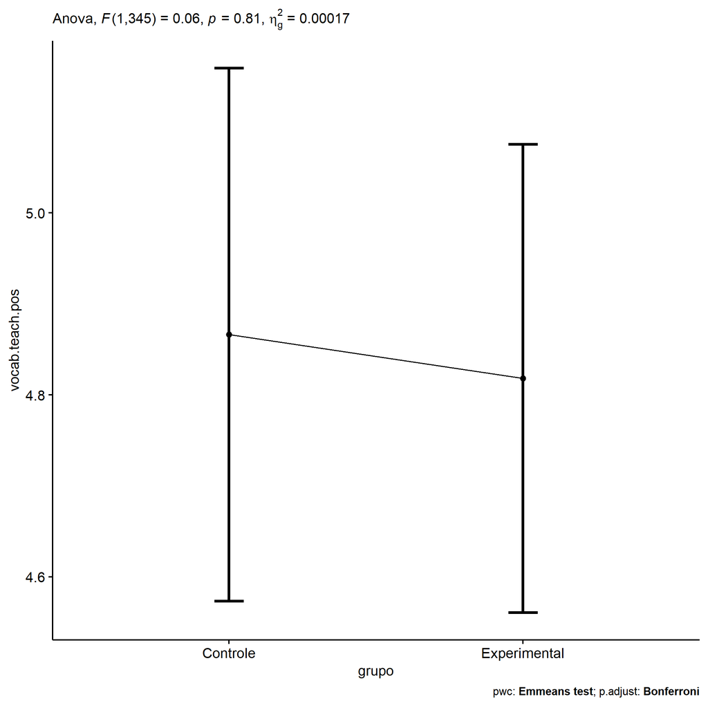

```r
if (!is.null(nrow(plots[["grupo"]]$data)))
  plots[["grupo"]] + ggplot2::scale_color_manual(values = color[["grupo"]])
```

```r
plots <- oneWayAncovaBoxPlots(
  wdat, "vocab.teach.pos", "grupo", aov, pwc, covar = "vocab.teach.pre",
  theme = "classic", color = color[["grupo"]],
  subtitle = which(aov$Effect == "grupo"))
```

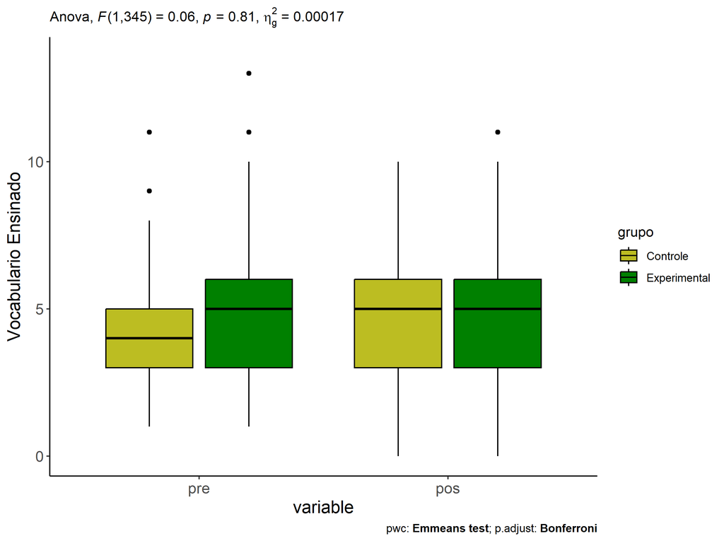

```r
if (length(unique(wdat[["grupo"]])) > 1)
  plots[["grupo"]] + ggplot2::ylab("Vocabulario Ensinado") + ggplot2::scale_x_discrete(labels=c('pre', 'pos'))
```

```r
if (length(unique(wdat.long[["grupo"]])) > 1)
  plots <- oneWayAncovaBoxPlots(
    wdat.long, "vocab.teach", "grupo", aov, pwc.long, pre.post = "time",
    theme = "classic", color = color$prepost)
```

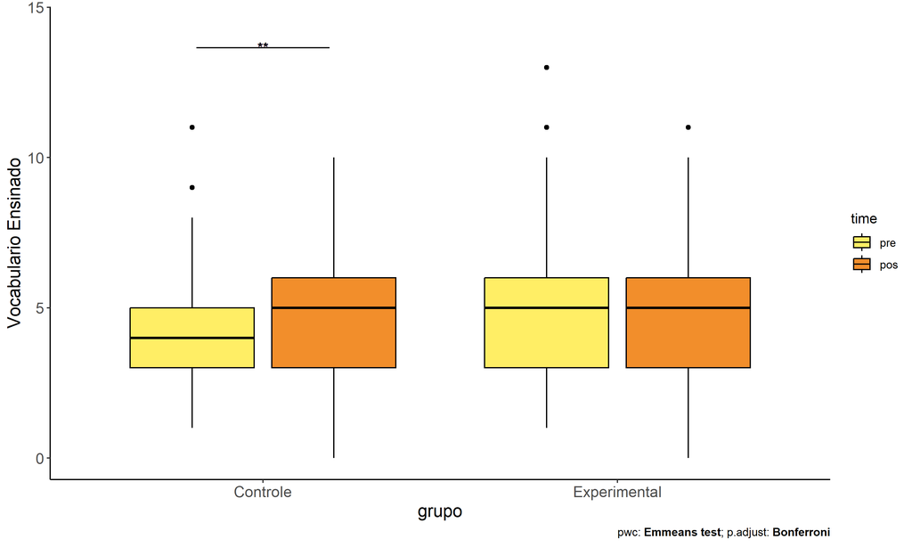

```r
if (length(unique(wdat.long[["grupo"]])) > 1)
  plots[["grupo"]] + ggplot2::ylab("Vocabulario Ensinado")
```

### Checking linearity assumption

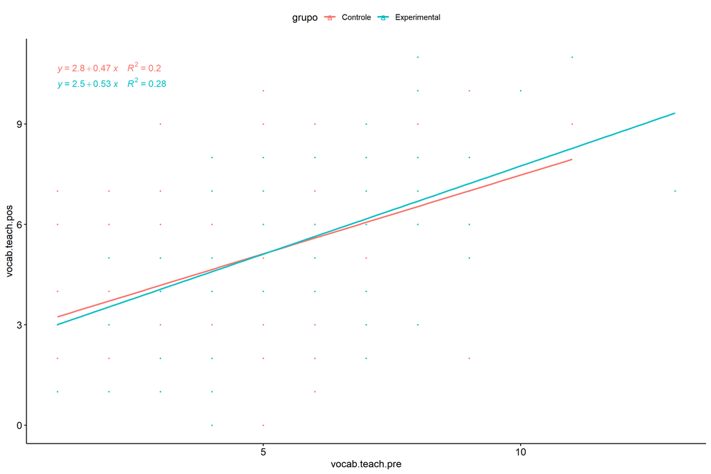

```r
ggscatter(wdat, x = "vocab.teach.pre", y = "vocab.teach.pos", size = 0.5,
          color = "grupo", add = "reg.line")+
  stat_regline_equation(
    aes(label =  paste(..eq.label.., ..rr.label.., sep = "~~~~"), color = grupo)
  )
```

### Checking normality and homogeneity

```r
res <- augment(lm(vocab.teach.pos ~ vocab.teach.pre + grupo, data = wdat))
```

```r
shapiro_test(res$.resid)
```

```
## # A tibble: 1 × 3
##   variable   statistic p.value
##   <chr>          <dbl>   <dbl>
## 1 res$.resid     0.992  0.0644
```

```r
levene_test(res, .resid ~ grupo)
```

```
## # A tibble: 1 × 4
##     df1   df2 statistic     p
##   <int> <int>     <dbl> <dbl>
## 1     1   346     0.561 0.454
```

# ANCOVA and Pairwise for two factors **grupo:Sexo**

## Without remove non-normal data

```r
pdat = remove_group_data(dat[!is.na(dat[["grupo"]]) & !is.na(dat[["Sexo"]]),], "vocab.teach.pos", c("grupo","Sexo"))

pdat.long <- rbind(pdat[,c("id","grupo","Sexo")], pdat[,c("id","grupo","Sexo")])
pdat.long[["time"]] <- c(rep("pre", nrow(pdat)), rep("pos", nrow(pdat)))
pdat.long[["time"]] <- factor(pdat.long[["time"]], c("pre","pos"))
pdat.long[["vocab.teach"]] <- c(pdat[["vocab.teach.pre"]], pdat[["vocab.teach.pos"]])

aov = anova_test(pdat, vocab.teach.pos ~ vocab.teach.pre + grupo*Sexo)
laov[["grupo:Sexo"]] <- get_anova_table(aov)
```

```r
pwcs <- list()
pwcs[["Sexo"]] <- emmeans_test(
  group_by(pdat, grupo), vocab.teach.pos ~ Sexo,
  covariate = vocab.teach.pre, p.adjust.method = "bonferroni")
pwcs[["grupo"]] <- emmeans_test(
  group_by(pdat, Sexo), vocab.teach.pos ~ grupo,
  covariate = vocab.teach.pre, p.adjust.method = "bonferroni")

pwc <- plyr::rbind.fill(pwcs[["grupo"]], pwcs[["Sexo"]])
pwc <- pwc[,c("grupo","Sexo", colnames(pwc)[!colnames(pwc) %in% c("grupo","Sexo")])]
```

```r
pwc.long <- emmeans_test(dplyr::group_by_at(pdat.long, c("grupo","Sexo")),
                         vocab.teach ~ time,
                         p.adjust.method = "bonferroni")
lpwc[["grupo:Sexo"]] <- plyr::rbind.fill(pwc, pwc.long)
```

```r
ds <- get.descriptives(pdat, "vocab.teach.pos", c("grupo","Sexo"), covar = "vocab.teach.pre")
ds <- merge(ds[ds$variable != "vocab.teach.pre",],
            ds[ds$variable == "vocab.teach.pre", !colnames(ds) %in% c("variable")],
            by = c("grupo","Sexo"), all.x = T, suffixes = c("", ".vocab.teach.pre"))
ds <- merge(get_emmeans(pwcs[["grupo"]]), ds, by = c("grupo","Sexo"), suffixes = c(".emms", ""))
ds <- ds[,c("grupo","Sexo","n","mean.vocab.teach.pre","se.vocab.teach.pre","mean","se","emmean","se.emms")]

colnames(ds) <- c("grupo","Sexo", "N", paste0(c("M","SE")," (pre)"),
                  paste0(c("M","SE"), " (unadj)"), paste0(c("M", "SE"), " (adj)"))

lemms[["grupo:Sexo"]] <- ds
```

## Computing ANCOVA and PairWise After removing non-normal data (OK)

```r
wdat = pdat

res = residuals(lm(vocab.teach.pos ~ vocab.teach.pre + grupo*Sexo, data = wdat))
non.normal = getNonNormal(res, wdat$id, plimit = 0.05)

wdat = wdat[!wdat$id %in% non.normal,]

wdat.long <- rbind(wdat[,c("id","grupo","Sexo")], wdat[,c("id","grupo","Sexo")])
wdat.long[["time"]] <- c(rep("pre", nrow(wdat)), rep("pos", nrow(wdat)))
wdat.long[["time"]] <- factor(wdat.long[["time"]], c("pre","pos"))
wdat.long[["vocab.teach"]] <- c(wdat[["vocab.teach.pre"]], wdat[["vocab.teach.pos"]])


ldat[["grupo:Sexo"]] = wdat

(non.normal)
```

```r
aov = anova_test(wdat, vocab.teach.pos ~ vocab.teach.pre + grupo*Sexo)
laov[["grupo:Sexo"]] <- merge(get_anova_table(aov), laov[["grupo:Sexo"]], by="Effect", suffixes = c("","'"))

(df = get_anova_table(aov))
```

```
## ANOVA Table (type II tests)
##
##            Effect DFn DFd       F        p p<.05      ges
## 1 vocab.teach.pre   1 343 111.543 9.21e-23     * 0.245000
## 2           grupo   1 343   0.043 8.37e-01       0.000124
## 3            Sexo   1 343   0.286 5.93e-01       0.000835
## 4      grupo:Sexo   1 343   0.082 7.75e-01       0.000239
```

| Effect | DFn | DFd | F | p | p<.05 | ges |
| --- | --- | --- | --- | --- | --- | --- |
| vocab.teach.pre | 1 | 343 | 111.543 | 0.000 | * | 0.245 |
| grupo | 1 | 343 | 0.043 | 0.837 |  | 0.000 |
| Sexo | 1 | 343 | 0.286 | 0.593 |  | 0.001 |
| grupo:Sexo | 1 | 343 | 0.082 | 0.775 |  | 0.000 |

```r
pwcs <- list()
pwcs[["Sexo"]] <- emmeans_test(
  group_by(wdat, grupo), vocab.teach.pos ~ Sexo,
  covariate = vocab.teach.pre, p.adjust.method = "bonferroni")
pwcs[["grupo"]] <- emmeans_test(
  group_by(wdat, Sexo), vocab.teach.pos ~ grupo,
  covariate = vocab.teach.pre, p.adjust.method = "bonferroni")

pwc <- plyr::rbind.fill(pwcs[["grupo"]], pwcs[["Sexo"]])
pwc <- pwc[,c("grupo","Sexo", colnames(pwc)[!colnames(pwc) %in% c("grupo","Sexo")])]
```

| grupo | Sexo | term | .y. | group1 | group2 | df | statistic | p | p.adj | p.adj.signif |
| --- | --- | --- | --- | --- | --- | --- | --- | --- | --- | --- |
|  | F | vocab.teach.pre*grupo | vocab.teach.pos | Controle | Experimental | 343 | -0.040 | 0.968 | 0.968 | ns |
|  | M | vocab.teach.pre*grupo | vocab.teach.pos | Controle | Experimental | 343 | 0.350 | 0.727 | 0.727 | ns |
| Controle |  | vocab.teach.pre*Sexo | vocab.teach.pos | F | M | 343 | 0.135 | 0.893 | 0.893 | ns |
| Experimental |  | vocab.teach.pre*Sexo | vocab.teach.pos | F | M | 343 | 0.591 | 0.555 | 0.555 | ns |

```r
pwc.long <- emmeans_test(dplyr::group_by_at(wdat.long, c("grupo","Sexo")),
                         vocab.teach ~ time,
                         p.adjust.method = "bonferroni")
lpwc[["grupo:Sexo"]] <- merge(plyr::rbind.fill(pwc, pwc.long), lpwc[["grupo:Sexo"]], by=c("grupo","Sexo","term",".y.","group1","group2"), suffixes = c("","'"))
```

| grupo | Sexo | term | .y. | group1 | group2 | df | statistic | p | p.adj | p.adj.signif |
| --- | --- | --- | --- | --- | --- | --- | --- | --- | --- | --- |
| Controle | F | time | vocab.teach | pre | pos | 688 | -1.700 | 0.090 | 0.090 | ns |
| Controle | M | time | vocab.teach | pre | pos | 688 | -2.165 | 0.031 | 0.031 | * |
| Experimental | F | time | vocab.teach | pre | pos | 688 | -1.205 | 0.229 | 0.229 | ns |
| Experimental | M | time | vocab.teach | pre | pos | 688 | -0.379 | 0.705 | 0.705 | ns |

```r
ds <- get.descriptives(wdat, "vocab.teach.pos", c("grupo","Sexo"), covar = "vocab.teach.pre")
ds <- merge(ds[ds$variable != "vocab.teach.pre",],
            ds[ds$variable == "vocab.teach.pre", !colnames(ds) %in% c("variable")],
            by = c("grupo","Sexo"), all.x = T, suffixes = c("", ".vocab.teach.pre"))
ds <- merge(get_emmeans(pwcs[["grupo"]]), ds, by = c("grupo","Sexo"), suffixes = c(".emms", ""))
ds <- ds[,c("grupo","Sexo","n","mean.vocab.teach.pre","se.vocab.teach.pre","mean","se","emmean","se.emms")]

colnames(ds) <- c("grupo","Sexo", "N", paste0(c("M","SE")," (pre)"),
                  paste0(c("M","SE"), " (unadj)"), paste0(c("M", "SE"), " (adj)"))

lemms[["grupo:Sexo"]] <- merge(ds, lemms[["grupo:Sexo"]], by=c("grupo","Sexo"), suffixes = c("","'"))
```

| grupo | Sexo | N | M (pre) | SE (pre) | M (unadj) | SE (unadj) | M (adj) | SE (adj) |
| --- | --- | --- | --- | --- | --- | --- | --- | --- |
| Controle | F | 85 | 4.259 | 0.192 | 4.800 | 0.214 | 4.884 | 0.198 |
| Controle | M | 67 | 3.701 | 0.253 | 4.478 | 0.260 | 4.844 | 0.226 |
| Experimental | F | 98 | 4.653 | 0.229 | 5.010 | 0.216 | 4.895 | 0.185 |
| Experimental | M | 98 | 4.837 | 0.207 | 4.949 | 0.216 | 4.741 | 0.185 |

### Plots for ancova

```r
plots <- twoWayAncovaPlots(
  wdat, "vocab.teach.pos", c("grupo","Sexo"), aov, pwcs, addParam = c("mean_se"),
  font.label.size=10, step.increase=0.05, p.label="p.adj",
  subtitle = which(aov$Effect == "grupo:Sexo"))
```

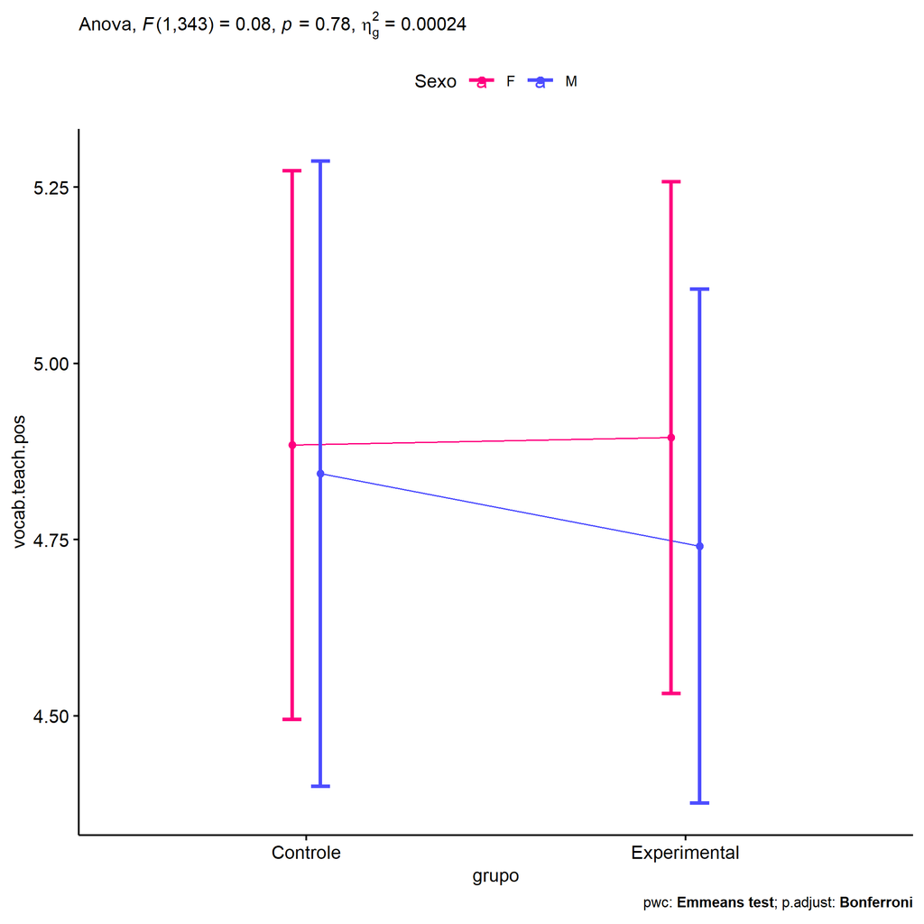

```r
if (!is.null(plots[["grupo"]]))
  plots[["grupo"]] + ggplot2::scale_color_manual(values = color[["Sexo"]])
```

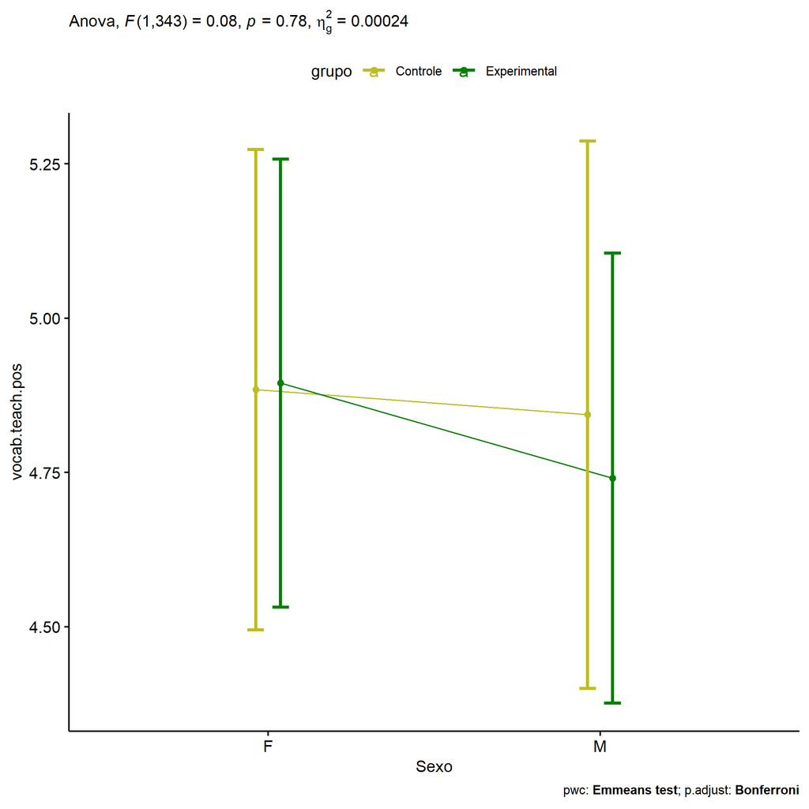

```r
if (!is.null(plots[["Sexo"]]))
  plots[["Sexo"]] + ggplot2::scale_color_manual(values = color[["grupo"]])
```

```r
plots <- twoWayAncovaBoxPlots(
  wdat, "vocab.teach.pos", c("grupo","Sexo"), aov, pwcs, covar = "vocab.teach.pre",
  theme = "classic", color = color[["grupo:Sexo"]],
  subtitle = which(aov$Effect == "grupo:Sexo"))
```

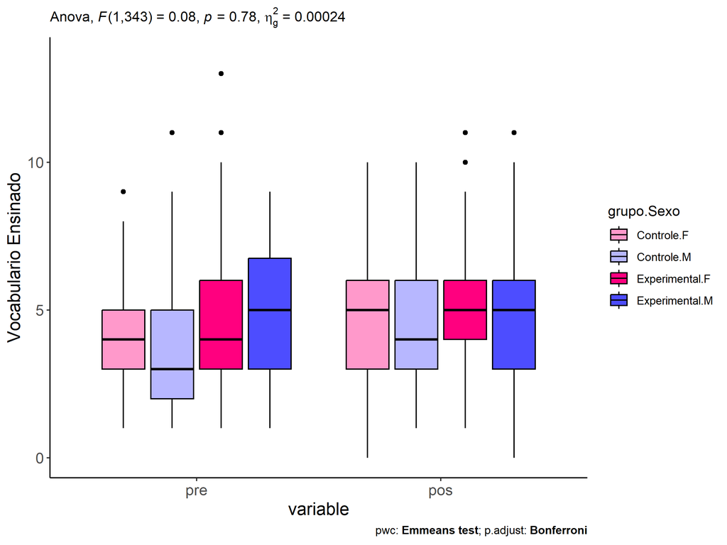

```r
plots[["grupo:Sexo"]] + ggplot2::ylab("Vocabulario Ensinado") + ggplot2::scale_x_discrete(labels=c('pre', 'pos'))
```

```r
plots <- twoWayAncovaBoxPlots(
  wdat.long, "vocab.teach", c("grupo","Sexo"), aov, pwc.long, pre.post = "time",
  theme = "classic", color = color$prepost)
```

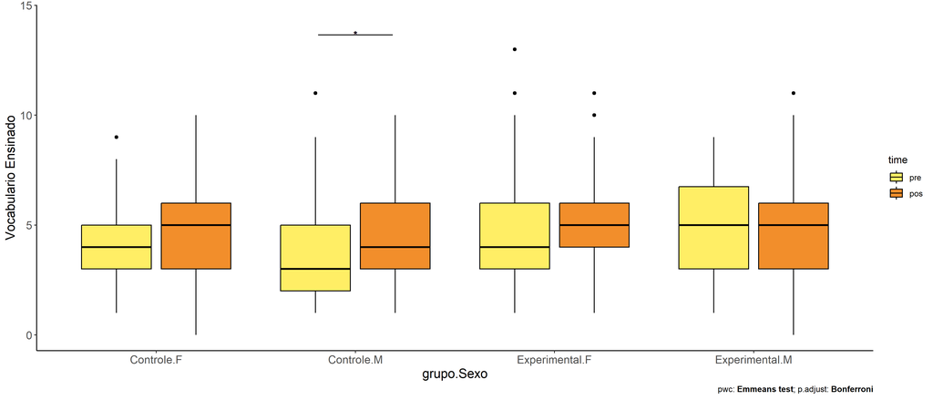

```r
plots[["grupo:Sexo"]] + ggplot2::ylab("Vocabulario Ensinado")
```

### Checking linearity assumption

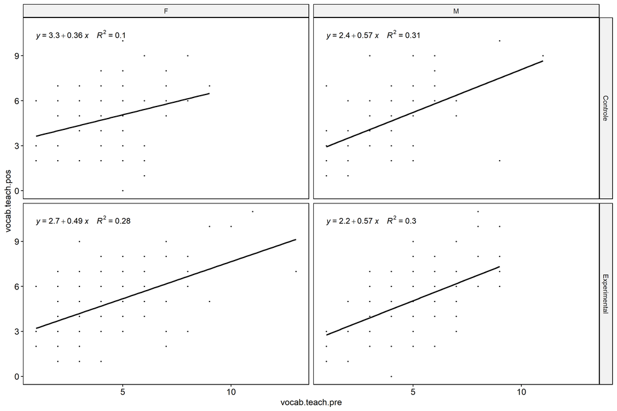

```r
ggscatter(wdat, x = "vocab.teach.pre", y = "vocab.teach.pos", size = 0.5,
          facet.by = c("grupo","Sexo"), add = "reg.line")+
  stat_regline_equation(
    aes(label =  paste(..eq.label.., ..rr.label.., sep = "~~~~"))
  )
```

### Checking normality and homogeneity

```r
res <- augment(lm(vocab.teach.pos ~ vocab.teach.pre + grupo*Sexo, data = wdat))
```

```r
shapiro_test(res$.resid)
```

```
## # A tibble: 1 × 3
##   variable   statistic p.value
##   <chr>          <dbl>   <dbl>
## 1 res$.resid     0.994   0.202
```

```r
levene_test(res, .resid ~ grupo*Sexo)
```

```
## # A tibble: 1 × 4
##     df1   df2 statistic     p
##   <int> <int>     <dbl> <dbl>
## 1     3   344     0.418 0.740
```

# ANCOVA and Pairwise for two factors **grupo:Zona**

## Without remove non-normal data

```r
pdat = remove_group_data(dat[!is.na(dat[["grupo"]]) & !is.na(dat[["Zona"]]),], "vocab.teach.pos", c("grupo","Zona"))

pdat.long <- rbind(pdat[,c("id","grupo","Zona")], pdat[,c("id","grupo","Zona")])
pdat.long[["time"]] <- c(rep("pre", nrow(pdat)), rep("pos", nrow(pdat)))
pdat.long[["time"]] <- factor(pdat.long[["time"]], c("pre","pos"))
pdat.long[["vocab.teach"]] <- c(pdat[["vocab.teach.pre"]], pdat[["vocab.teach.pos"]])

aov = anova_test(pdat, vocab.teach.pos ~ vocab.teach.pre + grupo*Zona)
laov[["grupo:Zona"]] <- get_anova_table(aov)
```

```r
pwcs <- list()
pwcs[["Zona"]] <- emmeans_test(
  group_by(pdat, grupo), vocab.teach.pos ~ Zona,
  covariate = vocab.teach.pre, p.adjust.method = "bonferroni")
pwcs[["grupo"]] <- emmeans_test(
  group_by(pdat, Zona), vocab.teach.pos ~ grupo,
  covariate = vocab.teach.pre, p.adjust.method = "bonferroni")

pwc <- plyr::rbind.fill(pwcs[["grupo"]], pwcs[["Zona"]])
pwc <- pwc[,c("grupo","Zona", colnames(pwc)[!colnames(pwc) %in% c("grupo","Zona")])]
```

```r
pwc.long <- emmeans_test(dplyr::group_by_at(pdat.long, c("grupo","Zona")),
                         vocab.teach ~ time,
                         p.adjust.method = "bonferroni")
lpwc[["grupo:Zona"]] <- plyr::rbind.fill(pwc, pwc.long)
```

```r
ds <- get.descriptives(pdat, "vocab.teach.pos", c("grupo","Zona"), covar = "vocab.teach.pre")
ds <- merge(ds[ds$variable != "vocab.teach.pre",],
            ds[ds$variable == "vocab.teach.pre", !colnames(ds) %in% c("variable")],
            by = c("grupo","Zona"), all.x = T, suffixes = c("", ".vocab.teach.pre"))
ds <- merge(get_emmeans(pwcs[["grupo"]]), ds, by = c("grupo","Zona"), suffixes = c(".emms", ""))
ds <- ds[,c("grupo","Zona","n","mean.vocab.teach.pre","se.vocab.teach.pre","mean","se","emmean","se.emms")]

colnames(ds) <- c("grupo","Zona", "N", paste0(c("M","SE")," (pre)"),
                  paste0(c("M","SE"), " (unadj)"), paste0(c("M", "SE"), " (adj)"))

lemms[["grupo:Zona"]] <- ds
```

## Computing ANCOVA and PairWise After removing non-normal data (OK)

```r
wdat = pdat

res = residuals(lm(vocab.teach.pos ~ vocab.teach.pre + grupo*Zona, data = wdat))
non.normal = getNonNormal(res, wdat$id, plimit = 0.05)

wdat = wdat[!wdat$id %in% non.normal,]

wdat.long <- rbind(wdat[,c("id","grupo","Zona")], wdat[,c("id","grupo","Zona")])
wdat.long[["time"]] <- c(rep("pre", nrow(wdat)), rep("pos", nrow(wdat)))
wdat.long[["time"]] <- factor(wdat.long[["time"]], c("pre","pos"))
wdat.long[["vocab.teach"]] <- c(wdat[["vocab.teach.pre"]], wdat[["vocab.teach.pos"]])


ldat[["grupo:Zona"]] = wdat

(non.normal)
```

```r
aov = anova_test(wdat, vocab.teach.pos ~ vocab.teach.pre + grupo*Zona)
laov[["grupo:Zona"]] <- merge(get_anova_table(aov), laov[["grupo:Zona"]], by="Effect", suffixes = c("","'"))

(df = get_anova_table(aov))
```

```
## ANOVA Table (type II tests)
##
##            Effect DFn DFd      F        p p<.05      ges
## 1 vocab.teach.pre   1 289 97.070 6.21e-20     * 2.51e-01
## 2           grupo   1 289  0.015 9.04e-01       5.06e-05
## 3            Zona   1 289  1.116 2.92e-01       4.00e-03
## 4      grupo:Zona   1 289  1.526 2.18e-01       5.00e-03
```

| Effect | DFn | DFd | F | p | p<.05 | ges |
| --- | --- | --- | --- | --- | --- | --- |
| vocab.teach.pre | 1 | 289 | 97.070 | 0.000 | * | 0.251 |
| grupo | 1 | 289 | 0.015 | 0.904 |  | 0.000 |
| Zona | 1 | 289 | 1.116 | 0.292 |  | 0.004 |
| grupo:Zona | 1 | 289 | 1.526 | 0.218 |  | 0.005 |

```r
pwcs <- list()
pwcs[["Zona"]] <- emmeans_test(
  group_by(wdat, grupo), vocab.teach.pos ~ Zona,
  covariate = vocab.teach.pre, p.adjust.method = "bonferroni")
pwcs[["grupo"]] <- emmeans_test(
  group_by(wdat, Zona), vocab.teach.pos ~ grupo,
  covariate = vocab.teach.pre, p.adjust.method = "bonferroni")

pwc <- plyr::rbind.fill(pwcs[["grupo"]], pwcs[["Zona"]])
pwc <- pwc[,c("grupo","Zona", colnames(pwc)[!colnames(pwc) %in% c("grupo","Zona")])]
```

| grupo | Zona | term | .y. | group1 | group2 | df | statistic | p | p.adj | p.adj.signif |
| --- | --- | --- | --- | --- | --- | --- | --- | --- | --- | --- |
|  | Rural | vocab.teach.pre*grupo | vocab.teach.pos | Controle | Experimental | 289 | 0.885 | 0.377 | 0.377 | ns |
|  | Urbana | vocab.teach.pre*grupo | vocab.teach.pos | Controle | Experimental | 289 | -0.861 | 0.390 | 0.390 | ns |
| Controle |  | vocab.teach.pre*Zona | vocab.teach.pos | Rural | Urbana | 289 | 1.626 | 0.105 | 0.105 | ns |
| Experimental |  | vocab.teach.pre*Zona | vocab.teach.pos | Rural | Urbana | 289 | -0.001 | 0.999 | 0.999 | ns |

```r
pwc.long <- emmeans_test(dplyr::group_by_at(wdat.long, c("grupo","Zona")),
                         vocab.teach ~ time,
                         p.adjust.method = "bonferroni")
lpwc[["grupo:Zona"]] <- merge(plyr::rbind.fill(pwc, pwc.long), lpwc[["grupo:Zona"]], by=c("grupo","Zona","term",".y.","group1","group2"), suffixes = c("","'"))
```

| grupo | Zona | term | .y. | group1 | group2 | df | statistic | p | p.adj | p.adj.signif |
| --- | --- | --- | --- | --- | --- | --- | --- | --- | --- | --- |
| Controle | Rural | time | vocab.teach | pre | pos | 580 | -2.656 | 0.008 | 0.008 | ** |
| Controle | Urbana | time | vocab.teach | pre | pos | 580 | -0.812 | 0.417 | 0.417 | ns |
| Experimental | Rural | time | vocab.teach | pre | pos | 580 | -1.162 | 0.246 | 0.246 | ns |
| Experimental | Urbana | time | vocab.teach | pre | pos | 580 | -0.975 | 0.330 | 0.330 | ns |

```r
ds <- get.descriptives(wdat, "vocab.teach.pos", c("grupo","Zona"), covar = "vocab.teach.pre")
ds <- merge(ds[ds$variable != "vocab.teach.pre",],
            ds[ds$variable == "vocab.teach.pre", !colnames(ds) %in% c("variable")],
            by = c("grupo","Zona"), all.x = T, suffixes = c("", ".vocab.teach.pre"))
ds <- merge(get_emmeans(pwcs[["grupo"]]), ds, by = c("grupo","Zona"), suffixes = c(".emms", ""))
ds <- ds[,c("grupo","Zona","n","mean.vocab.teach.pre","se.vocab.teach.pre","mean","se","emmean","se.emms")]

colnames(ds) <- c("grupo","Zona", "N", paste0(c("M","SE")," (pre)"),
                  paste0(c("M","SE"), " (unadj)"), paste0(c("M", "SE"), " (adj)"))

lemms[["grupo:Zona"]] <- merge(ds, lemms[["grupo:Zona"]], by=c("grupo","Zona"), suffixes = c("","'"))
```

| grupo | Zona | N | M (pre) | SE (pre) | M (unadj) | SE (unadj) | M (adj) | SE (adj) |
| --- | --- | --- | --- | --- | --- | --- | --- | --- |
| Controle | Rural | 77 | 4.117 | 0.224 | 5.013 | 0.236 | 5.196 | 0.211 |
| Controle | Urbana | 50 | 4.140 | 0.230 | 4.480 | 0.265 | 4.651 | 0.262 |
| Experimental | Rural | 92 | 4.707 | 0.219 | 5.065 | 0.236 | 4.942 | 0.193 |
| Experimental | Urbana | 75 | 4.760 | 0.268 | 5.093 | 0.251 | 4.942 | 0.214 |

### Plots for ancova

```r
plots <- twoWayAncovaPlots(
  wdat, "vocab.teach.pos", c("grupo","Zona"), aov, pwcs, addParam = c("mean_se"),
  font.label.size=10, step.increase=0.05, p.label="p.adj",
  subtitle = which(aov$Effect == "grupo:Zona"))
```

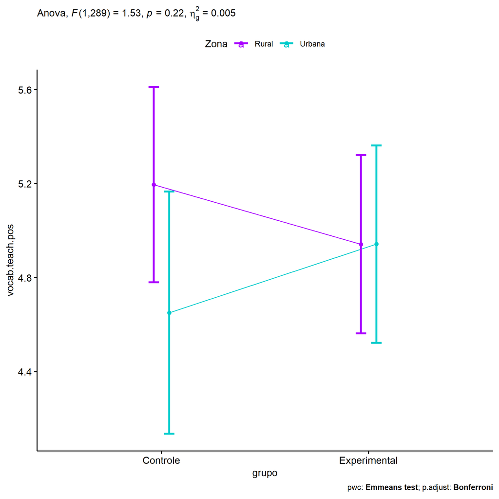

```r
if (!is.null(plots[["grupo"]]))
  plots[["grupo"]] + ggplot2::scale_color_manual(values = color[["Zona"]])
```

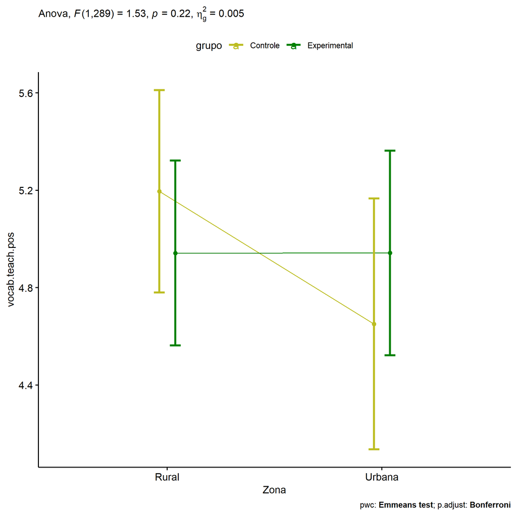

```r
if (!is.null(plots[["Zona"]]))
  plots[["Zona"]] + ggplot2::scale_color_manual(values = color[["grupo"]])
```

```r
plots <- twoWayAncovaBoxPlots(
  wdat, "vocab.teach.pos", c("grupo","Zona"), aov, pwcs, covar = "vocab.teach.pre",
  theme = "classic", color = color[["grupo:Zona"]],
  subtitle = which(aov$Effect == "grupo:Zona"))
```

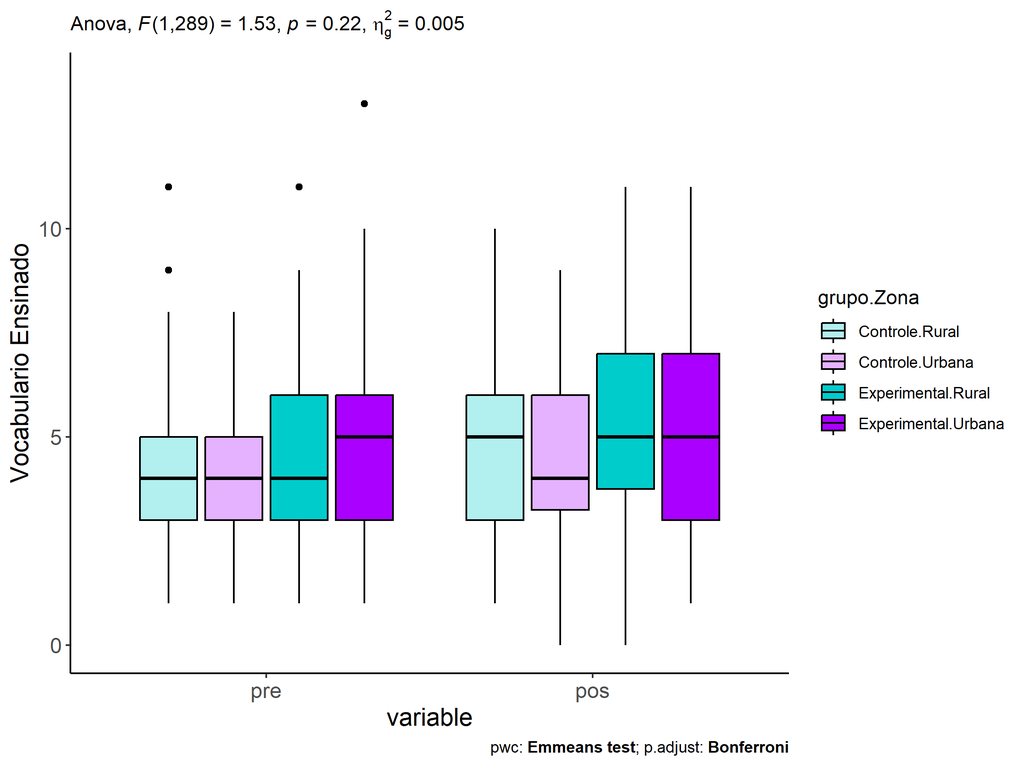

```r
plots[["grupo:Zona"]] + ggplot2::ylab("Vocabulario Ensinado") + ggplot2::scale_x_discrete(labels=c('pre', 'pos'))
```

```r
plots <- twoWayAncovaBoxPlots(
  wdat.long, "vocab.teach", c("grupo","Zona"), aov, pwc.long, pre.post = "time",
  theme = "classic", color = color$prepost)
```

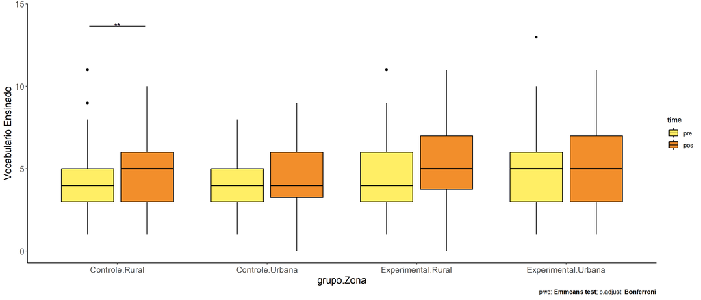

```r
plots[["grupo:Zona"]] + ggplot2::ylab("Vocabulario Ensinado")
```

### Checking linearity assumption

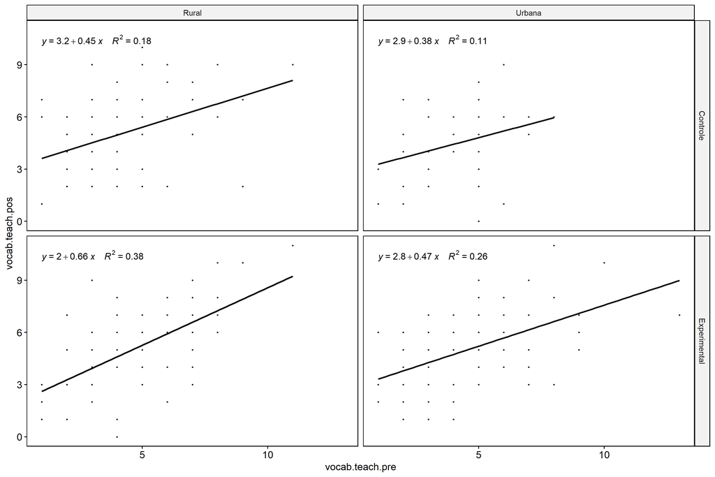

```r
ggscatter(wdat, x = "vocab.teach.pre", y = "vocab.teach.pos", size = 0.5,
          facet.by = c("grupo","Zona"), add = "reg.line")+
  stat_regline_equation(
    aes(label =  paste(..eq.label.., ..rr.label.., sep = "~~~~"))
  )
```

### Checking normality and homogeneity

```r
res <- augment(lm(vocab.teach.pos ~ vocab.teach.pre + grupo*Zona, data = wdat))
```

```r
shapiro_test(res$.resid)
```

```
## # A tibble: 1 × 3
##   variable   statistic p.value
##   <chr>          <dbl>   <dbl>
## 1 res$.resid     0.997   0.812
```

```r
levene_test(res, .resid ~ grupo*Zona)
```

```
## # A tibble: 1 × 4
##     df1   df2 statistic     p
##   <int> <int>     <dbl> <dbl>
## 1     3   290     0.525 0.666
```

# ANCOVA and Pairwise for two factors **grupo:Cor.Raca**

## Without remove non-normal data

```r
pdat = remove_group_data(dat[!is.na(dat[["grupo"]]) & !is.na(dat[["Cor.Raca"]]),], "vocab.teach.pos", c("grupo","Cor.Raca"))

pdat.long <- rbind(pdat[,c("id","grupo","Cor.Raca")], pdat[,c("id","grupo","Cor.Raca")])
pdat.long[["time"]] <- c(rep("pre", nrow(pdat)), rep("pos", nrow(pdat)))
pdat.long[["time"]] <- factor(pdat.long[["time"]], c("pre","pos"))
pdat.long[["vocab.teach"]] <- c(pdat[["vocab.teach.pre"]], pdat[["vocab.teach.pos"]])

aov = anova_test(pdat, vocab.teach.pos ~ vocab.teach.pre + grupo*Cor.Raca)
laov[["grupo:Cor.Raca"]] <- get_anova_table(aov)
```

```r
pwcs <- list()
pwcs[["Cor.Raca"]] <- emmeans_test(
  group_by(pdat, grupo), vocab.teach.pos ~ Cor.Raca,
  covariate = vocab.teach.pre, p.adjust.method = "bonferroni")
pwcs[["grupo"]] <- emmeans_test(
  group_by(pdat, Cor.Raca), vocab.teach.pos ~ grupo,
  covariate = vocab.teach.pre, p.adjust.method = "bonferroni")

pwc <- plyr::rbind.fill(pwcs[["grupo"]], pwcs[["Cor.Raca"]])
pwc <- pwc[,c("grupo","Cor.Raca", colnames(pwc)[!colnames(pwc) %in% c("grupo","Cor.Raca")])]
```

```r
pwc.long <- emmeans_test(dplyr::group_by_at(pdat.long, c("grupo","Cor.Raca")),
                         vocab.teach ~ time,
                         p.adjust.method = "bonferroni")
lpwc[["grupo:Cor.Raca"]] <- plyr::rbind.fill(pwc, pwc.long)
```

```r
ds <- get.descriptives(pdat, "vocab.teach.pos", c("grupo","Cor.Raca"), covar = "vocab.teach.pre")
ds <- merge(ds[ds$variable != "vocab.teach.pre",],
            ds[ds$variable == "vocab.teach.pre", !colnames(ds) %in% c("variable")],
            by = c("grupo","Cor.Raca"), all.x = T, suffixes = c("", ".vocab.teach.pre"))
ds <- merge(get_emmeans(pwcs[["grupo"]]), ds, by = c("grupo","Cor.Raca"), suffixes = c(".emms", ""))
ds <- ds[,c("grupo","Cor.Raca","n","mean.vocab.teach.pre","se.vocab.teach.pre","mean","se","emmean","se.emms")]

colnames(ds) <- c("grupo","Cor.Raca", "N", paste0(c("M","SE")," (pre)"),
                  paste0(c("M","SE"), " (unadj)"), paste0(c("M", "SE"), " (adj)"))

lemms[["grupo:Cor.Raca"]] <- ds
```

## Computing ANCOVA and PairWise After removing non-normal data (OK)

```r
wdat = pdat

res = residuals(lm(vocab.teach.pos ~ vocab.teach.pre + grupo*Cor.Raca, data = wdat))
non.normal = getNonNormal(res, wdat$id, plimit = 0.05)

wdat = wdat[!wdat$id %in% non.normal,]

wdat.long <- rbind(wdat[,c("id","grupo","Cor.Raca")], wdat[,c("id","grupo","Cor.Raca")])
wdat.long[["time"]] <- c(rep("pre", nrow(wdat)), rep("pos", nrow(wdat)))
wdat.long[["time"]] <- factor(wdat.long[["time"]], c("pre","pos"))
wdat.long[["vocab.teach"]] <- c(wdat[["vocab.teach.pre"]], wdat[["vocab.teach.pos"]])


ldat[["grupo:Cor.Raca"]] = wdat

(non.normal)
```

```r
aov = anova_test(wdat, vocab.teach.pos ~ vocab.teach.pre + grupo*Cor.Raca)
laov[["grupo:Cor.Raca"]] <- merge(get_anova_table(aov), laov[["grupo:Cor.Raca"]], by="Effect", suffixes = c("","'"))

(df = get_anova_table(aov))
```

```
## ANOVA Table (type II tests)
##
##            Effect DFn DFd      F        p p<.05   ges
## 1 vocab.teach.pre   1 132 43.249 1.03e-09     * 0.247
## 2           grupo   1 132  1.385 2.41e-01       0.010
## 3        Cor.Raca   2 132  1.942 1.48e-01       0.029
## 4  grupo:Cor.Raca   1 132  0.717 3.99e-01       0.005
```

| Effect | DFn | DFd | F | p | p<.05 | ges |
| --- | --- | --- | --- | --- | --- | --- |
| vocab.teach.pre | 1 | 132 | 43.249 | 0.000 | * | 0.247 |
| grupo | 1 | 132 | 1.385 | 0.241 |  | 0.010 |
| Cor.Raca | 2 | 132 | 1.942 | 0.148 |  | 0.029 |
| grupo:Cor.Raca | 1 | 132 | 0.717 | 0.399 |  | 0.005 |

```r
pwcs <- list()
pwcs[["Cor.Raca"]] <- emmeans_test(
  group_by(wdat, grupo), vocab.teach.pos ~ Cor.Raca,
  covariate = vocab.teach.pre, p.adjust.method = "bonferroni")
pwcs[["grupo"]] <- emmeans_test(
  group_by(wdat, Cor.Raca), vocab.teach.pos ~ grupo,
  covariate = vocab.teach.pre, p.adjust.method = "bonferroni")

pwc <- plyr::rbind.fill(pwcs[["grupo"]], pwcs[["Cor.Raca"]])
pwc <- pwc[,c("grupo","Cor.Raca", colnames(pwc)[!colnames(pwc) %in% c("grupo","Cor.Raca")])]
```

| grupo | Cor.Raca | term | .y. | group1 | group2 | df | statistic | p | p.adj | p.adj.signif |
| --- | --- | --- | --- | --- | --- | --- | --- | --- | --- | --- |
|  | Branca | vocab.teach.pre*grupo | vocab.teach.pos | Controle | Experimental | 132 | -0.144 | 0.886 | 0.886 | ns |
|  | Indígena | vocab.teach.pre*grupo | vocab.teach.pos | Controle | Experimental |  |  |  |  |  |
|  | Parda | vocab.teach.pre*grupo | vocab.teach.pos | Controle | Experimental | 132 | 1.441 | 0.152 | 0.152 | ns |
| Controle |  | vocab.teach.pre*Cor.Raca | vocab.teach.pos | Branca | Indígena | 132 | -2.051 | 0.042 | 0.127 | ns |
| Controle |  | vocab.teach.pre*Cor.Raca | vocab.teach.pos | Branca | Parda | 132 | -1.430 | 0.155 | 0.466 | ns |
| Controle |  | vocab.teach.pre*Cor.Raca | vocab.teach.pos | Indígena | Parda | 132 | 1.231 | 0.221 | 0.662 | ns |
| Experimental |  | vocab.teach.pre*Cor.Raca | vocab.teach.pos | Branca | Indígena |  |  |  |  |  |
| Experimental |  | vocab.teach.pre*Cor.Raca | vocab.teach.pos | Branca | Parda | 132 | -0.074 | 0.941 | 0.941 | ns |
| Experimental |  | vocab.teach.pre*Cor.Raca | vocab.teach.pos | Indígena | Parda |  |  |  |  |  |

```r
pwc.long <- emmeans_test(dplyr::group_by_at(wdat.long, c("grupo","Cor.Raca")),
                         vocab.teach ~ time,
                         p.adjust.method = "bonferroni")
lpwc[["grupo:Cor.Raca"]] <- merge(plyr::rbind.fill(pwc, pwc.long), lpwc[["grupo:Cor.Raca"]], by=c("grupo","Cor.Raca","term",".y.","group1","group2"), suffixes = c("","'"))
```

| grupo | Cor.Raca | term | .y. | group1 | group2 | df | statistic | p | p.adj | p.adj.signif |
| --- | --- | --- | --- | --- | --- | --- | --- | --- | --- | --- |
| Controle | Branca | time | vocab.teach | pre | pos | 266 | -0.847 | 0.398 | 0.398 | ns |
| Controle | Indígena | time | vocab.teach | pre | pos | 266 | -2.042 | 0.042 | 0.042 | * |
| Controle | Parda | time | vocab.teach | pre | pos | 266 | -3.047 | 0.003 | 0.003 | ** |
| Experimental | Branca | time | vocab.teach | pre | pos | 266 | -0.417 | 0.677 | 0.677 | ns |
| Experimental | Indígena | time | vocab.teach | pre | pos |  |  |  |  |  |
| Experimental | Parda | time | vocab.teach | pre | pos | 266 | -1.151 | 0.251 | 0.251 | ns |

```r
ds <- get.descriptives(wdat, "vocab.teach.pos", c("grupo","Cor.Raca"), covar = "vocab.teach.pre")
ds <- merge(ds[ds$variable != "vocab.teach.pre",],
            ds[ds$variable == "vocab.teach.pre", !colnames(ds) %in% c("variable")],
            by = c("grupo","Cor.Raca"), all.x = T, suffixes = c("", ".vocab.teach.pre"))
ds <- merge(get_emmeans(pwcs[["grupo"]]), ds, by = c("grupo","Cor.Raca"), suffixes = c(".emms", ""))
ds <- ds[,c("grupo","Cor.Raca","n","mean.vocab.teach.pre","se.vocab.teach.pre","mean","se","emmean","se.emms")]

colnames(ds) <- c("grupo","Cor.Raca", "N", paste0(c("M","SE")," (pre)"),
                  paste0(c("M","SE"), " (unadj)"), paste0(c("M", "SE"), " (adj)"))

lemms[["grupo:Cor.Raca"]] <- merge(ds, lemms[["grupo:Cor.Raca"]], by=c("grupo","Cor.Raca"), suffixes = c("","'"))
```

| grupo | Cor.Raca | N | M (pre) | SE (pre) | M (unadj) | SE (unadj) | M (adj) | SE (adj) |
| --- | --- | --- | --- | --- | --- | --- | --- | --- |
| Controle | Branca | 22 | 4.000 | 0.488 | 4.500 | 0.404 | 4.543 | 0.362 |
| Controle | Indígena | 8 | 3.875 | 0.515 | 5.875 | 0.693 | 5.979 | 0.600 |
| Controle | Parda | 44 | 3.727 | 0.277 | 5.000 | 0.300 | 5.176 | 0.257 |
| Experimental | Branca | 12 | 4.500 | 0.452 | 4.833 | 0.548 | 4.631 | 0.491 |
| Experimental | Parda | 52 | 4.365 | 0.288 | 4.808 | 0.269 | 4.671 | 0.236 |